# (Ford gobike share system insights)

## by (Ahmed Lotfy)

## Investigation Overview

> The Following visuals focus on 2 Main Variables: "User type" and "Duration" and what are the features that interact with.

## Dataset Overview

> "This data set includes information about individual rides made in a bike-sharing system covering the greater San Francisco Bay area" for the period of Februry 2019.

## Univariate Exploration:

## 1- the distribution of main variable of interest: "Duration" .

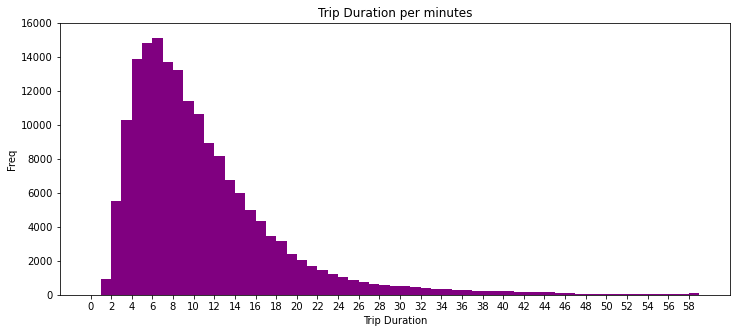

> - **Visual insight**:
- Since trip duration distribution has right skwed shape which means that lots of points refer to low values, with a very long tail of points refer to large values: Most trips duration approximately in range (3-12) minutes. And very few trips duration lasted more than one hour (60 minutes).

## 2- "Time of trip" distribution :"Start hour of the day" & "End hour of the day" distributions.

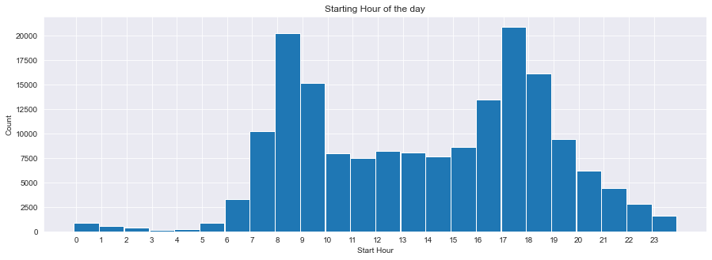

> **Visual insight:**
- The distribution seems roughly bimodal (has two peaks) at (8 AM) and (5 PM). Further specified analysis could examine if that correlated to factor of being most of work days start and end around thoes times.

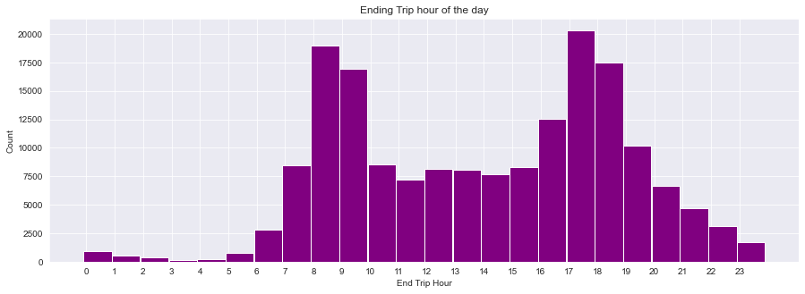

> **Visual insight:**
> - The distribution of end trips hours also seems roughly bimodal (has two peaks) at (8 AM) and (5 PM). Which supports the Further specified analysis hypothesis that suggests: there is a positive correlation between times of trips and being most of work days start and end around those times.

## 3- "Date of trips" distribution: "Start day of the week" distributions

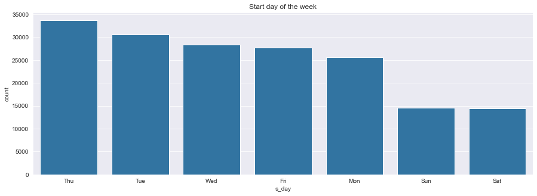

> **Visual insight:**
> - The distribution of "start day of week" trips date also seems related to "work days" [Monday-Friday] which supports giving priority to "going to Work" as a main purpose of using "ford gobike" service.

## 4- Ages of users" distributions

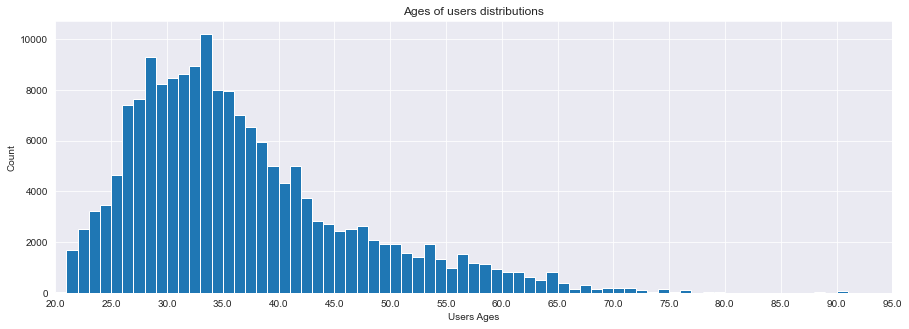

##### Also we can look at that croped graph

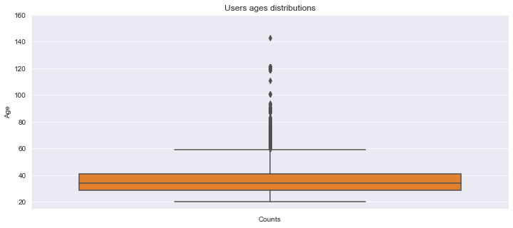

> **Visual insight:**
> - "Users ages" approximately seems in range (20 - 60) with few higher values outliers, about 75% of users is less than 40 years old, and 90% less than 60 years old which support the suggestion of going to work is a main purpose of using "ford gobike" service.

# Bivariate Exploration

> I will go first with the User-wise prospective so i will focus first on:
> - User type VS duration per minutes.
> - User type VS Date.
> - User type Vs Age

### 1- User type Vs duration per minutes distributions:

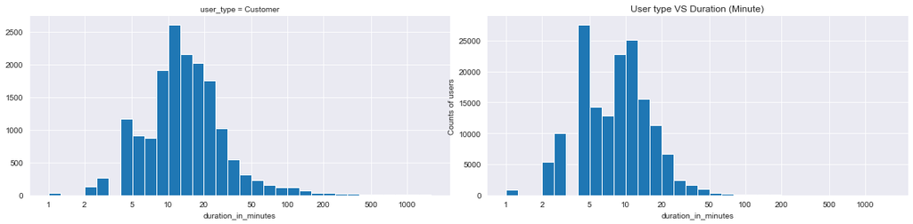

> **Visual insight:**

**Subscriber user type:**

Duration of trips for Subscribers mostly in range (5-12) minutes. while:

**Customer user type**

Mostly rode in range (8-20) minutes which surprisingly is longer range . Also customers seems likely to last more than one hour compared to subscribers.

It seems like subscribers have a more specific usage or targeted porpused riding the bikes compared to customers who vary more.

### 2- User type Vs Date [day of the week]:

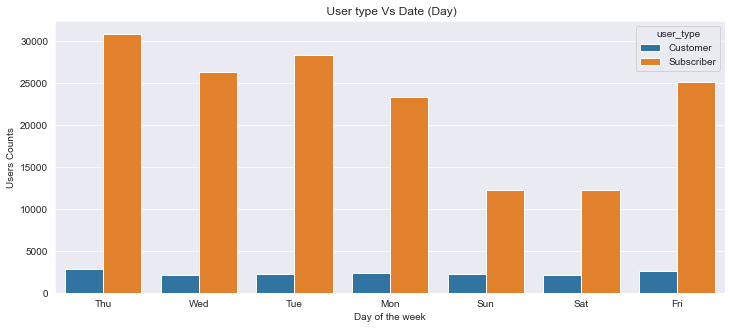

> **Visual insight:**

**Customers**

seem to have a roughly uniform pattern of using the "ford gobike" service through all weekdays. while

**Subscribers**

seem to have a dual pattern of using the "ford gobike" service through all weekdays, large amount of subscribers uses the service through [Mondays - fridays] but on [Suterdays- Sundays] number of subscribers who uses the service falls down, which supports the hypothesis of "going to work" as a main motive for subscribers.

### 3- User type Vs Age:

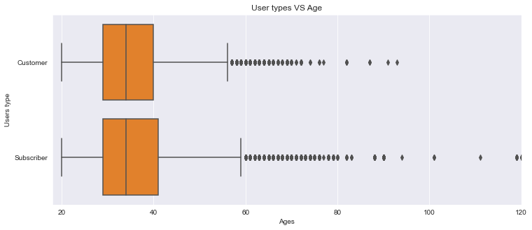

> **Visual insight:**

**Subscribers**

seem not only slightly older than customers, but also they have a wider range of ages as well.

### 4- User type Vs Gender:

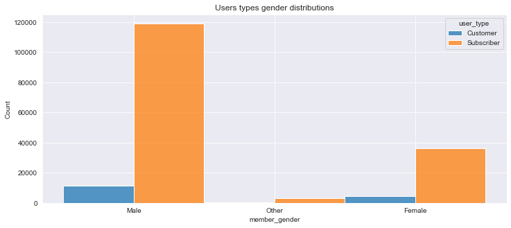

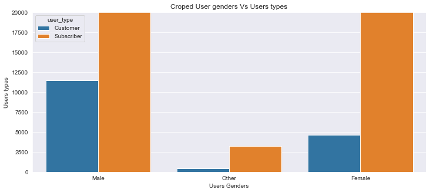

> **Visual insight:**

**Subscribers**

seem more diversitive, they are males ,females and other, also customers have the same diversity: males and females with slightly higher proportion for females than the subscribers.

## Multivariate Exploration

- User types Vs Ages Vs Genders.
- Ages Vs Genders Vs Durations per minutes.

### 1- User type VS Users ages VS Genders :

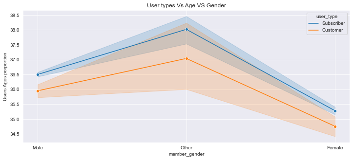

> **Visual insight:**

**Subscribers**

generally seem to have higher rates of ages among all types of genders, also females generally seem to be among younger subscribers and customers. we can have a deeper look in the following graph.

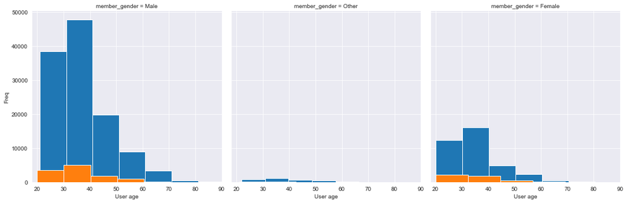

> Visual insight:
- Generally the range of ages of males ages is ( 20-60) for subscribers and suctomers, while most of "other" gender type subscribers in range ( 22- 58), also females in range (20 - 60) for both subscribers and customers same as males.
- I will separate the users' counts of each gender type to have a deeper look.

### Another plot to have a deeper look on age , gender and user type

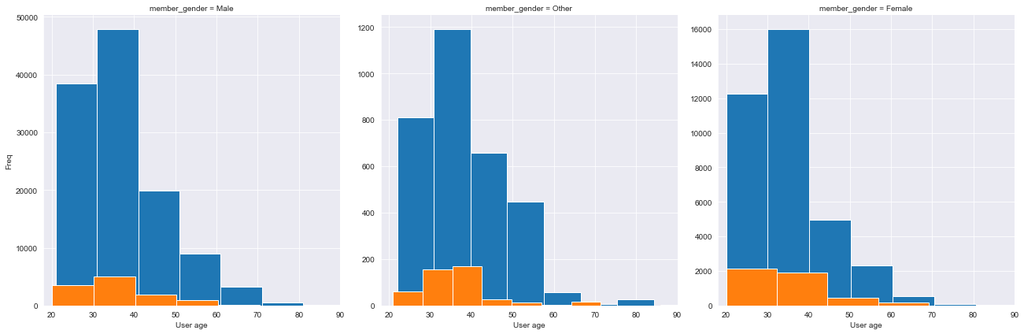

> **Visual insight:**
- Customers with genders types: Male and Other. seem slightly younger than subscribers with the same types, while both subscribers and customers females have the same younger ages ranges.
- Female customers in range (20-30) seems to be the peak of female customers while female subscribers peak seems to be in range (30-40) same as males customers and subscribers also same as "other" gender type peak.

### 2- Users ages VS Genders VS Duration :

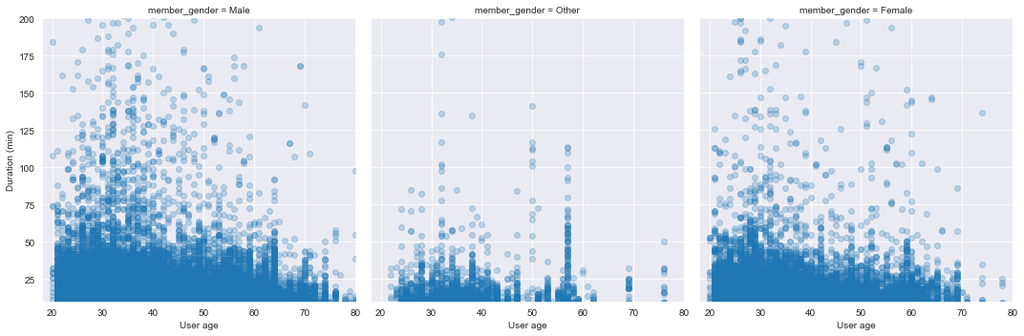

> **Visual insight:**
- Generally both Males and females in range (20-60) have the same pattern of trips durations (right skewed curve shape) which means that length of trip duration has inversely proportional relationship with Age while the "other" type gender has a unique bimodal pattern (has two peaks in range (30-40) and range (55-60).

i will crop the graph to have a deeper understanding of these patterns.

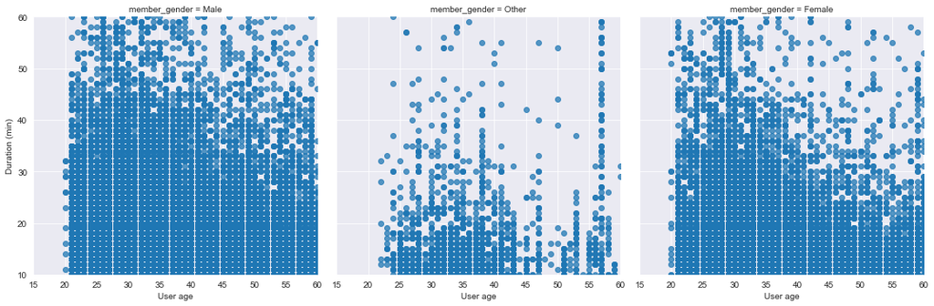

> **Visual insight:**
- Males trips durations last for more than (35 minutes) length in range (20-53) years old, while femals' lasts for the same length in range (20-45) years old. also both males and females trips durations last for (20 minutes) length in the same age range (20-60) years old.
- "Other" gender type has a unique dual pattern, durations of trips mostly last for (20 minutes) in range (24- 41) years old, but in range (55-60) years old surprisingly trips durations lasts for more than (50 minutes) , which seems an outlier for the "Other" gender type but it seem normal pattern as it is for both males and females.

The next graph will focus on outliers and special cases.

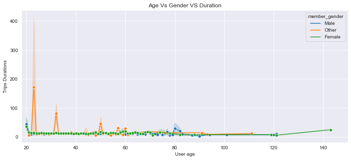

In the following graph i will crop more to focus on longest trips durations.

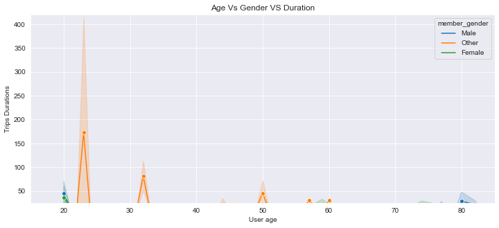

In the following graph i will crop more to focus on oldest users.

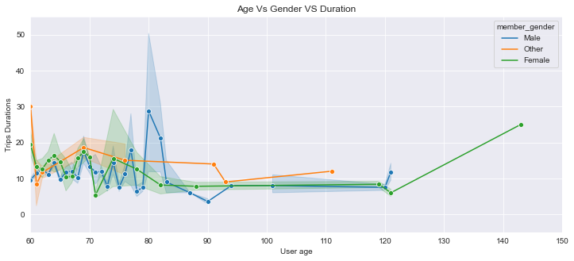

**IN General** we can say: